# A3: SPL Library Checkouts

### Introduction

I chose to analyze data on books with subjects that include “Self Help” in the years 2005-2022. In recent years, mental health conditions have increased world-wide. Many mental health awareness movements have emerged to emphasize the importance of mental health and pushed the topic to the forefront of people’s minds. Coming out of a period with large historic events, such as the 2020 Black Lives Matter protests and the COVID-19 pandemic, there has been tremendous unseen impacts on mental health. I am curious to see if this shift in self-wellness is reflected in Seattle Public Library book checkouts.

### The Dataset

The Seattle government collects data from the Seattle Public Library. The data is collected from 2005 to current day and collected initial checkouts of physical and electronic media like books, eBook, audio books, movies, etc. available at the library. Checkout data comes from multiple current and historical records. For digital items, they get data from media vendors like, Overdrive, hoopla, Freegal, and RBDigital. This data is collected due to an open data initiative to get information on which books are being circulated and what people are reading. Some ethical concerns I have about this data is how it ensures privacy for the individuals checking out. The legal media that you choose to consumer should be at your own discretion. If they can track which books are being checked out, how are the guaranteeing anonymity to the consumer? One limitation to this data is the records available. This data does not go beyond 2005 and it’s data for the year 2023 is incomplete, for this reason I chose to filter out 2023. Some other problems include the inconsistent publications dates and repeat titles.

### First Trends Over Time Chart

This line chart shows the trends of digital and physical “self help” media being checked out from the Seattle Public Library in 2005-2022. I included this chart because they way in which people are consuming media has become more digital. I wanted to visualize at which rate are physical and digital media being consumed and how it was affected during 2020, when many people could not go to the library to get physical media. I noticed that the plot and line for physical usage class dipped near 2019-2020. On the other hand, digital media has been checked out at an exponential rate, overtaking physical media around 2018.

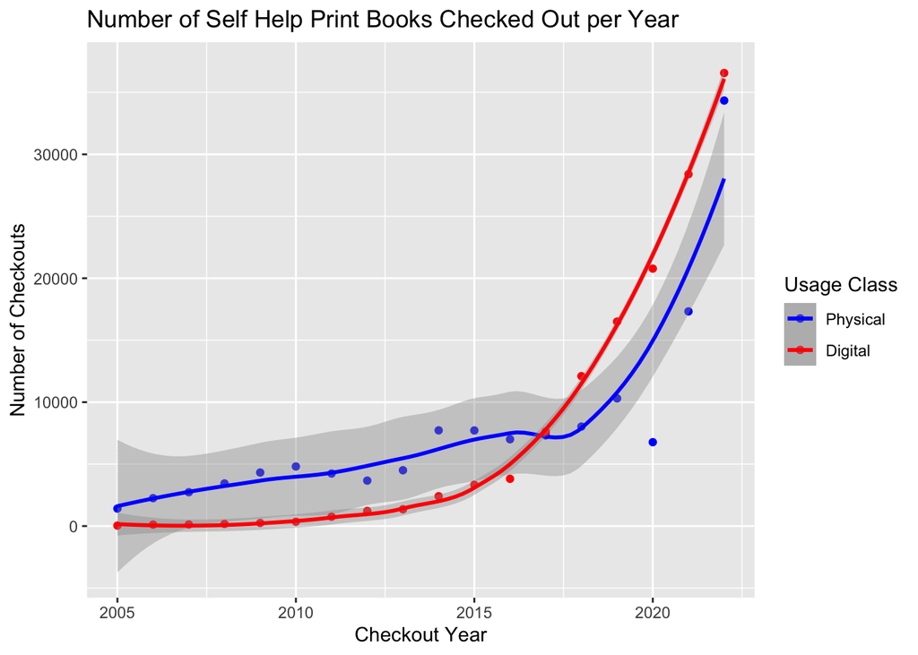

### Second Trends Over Time Chart

This stacked bar chart shows the trends of fiction and nonfiction “self help” media being checked out from the Seattle Public Library in 2005-2022. I included this because I was curious what proportional of self help books are fiction vs nonfiction, and which genre gets checked out more. I wanted to visualize which genre more people tend to checkout. I noticed that chart that in the past, nonfiction self help books were not very popular, however because more popular in 2018-2021. In 2022, it seems that fiction and nonfiction self help books are similarly checked out.

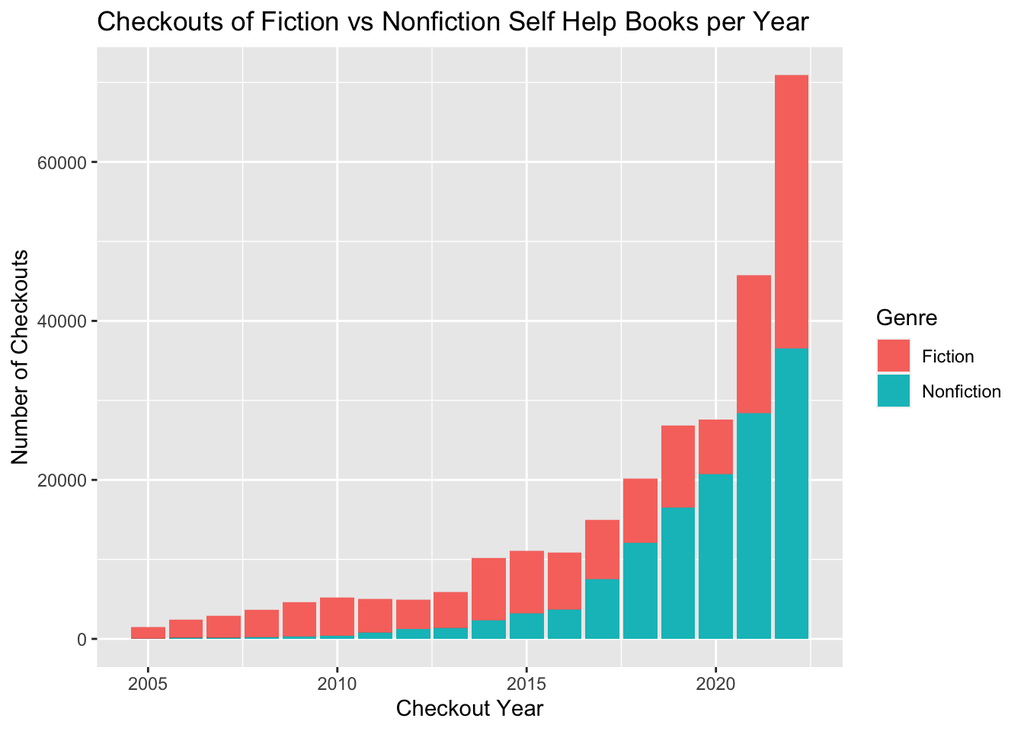

### Your Choice

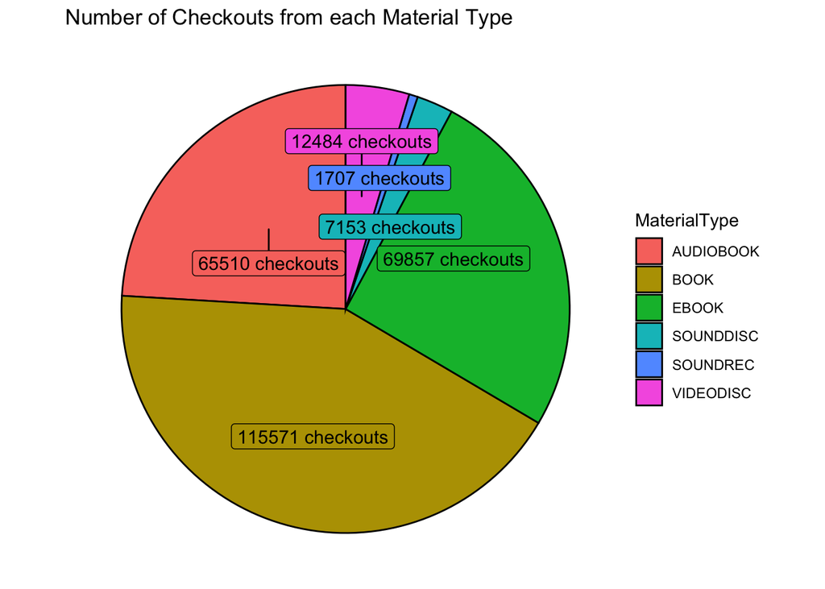